Yongsang Park

# 1 QQ plots

The normal distribution QQ plot is

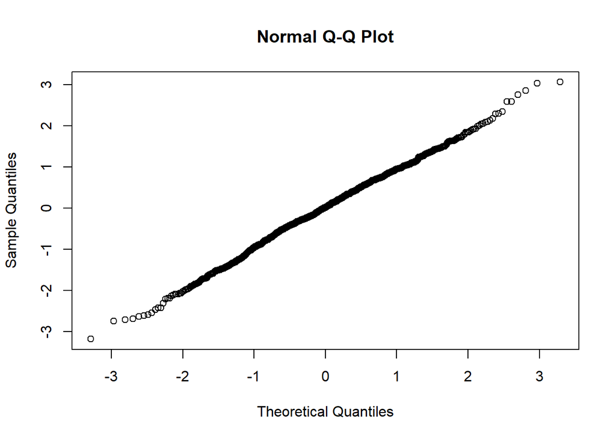

```r
qqnorm(rnorm(1000))
```

and I will compare this QQ plot with the other plots.

## 1a

The qq plot of the data is

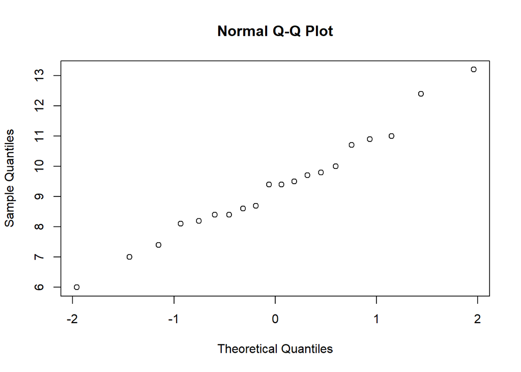

```r
dataA = c(7,13.2,8.1,8.2,6,9.5,9.4,8.7,9.8,10.9,8.4,7.4,8.4,10,9.7,8.6,12.4,10.7,11,9.4)
qqnorm(dataA)
```

and compare to the normal distribution QQ plot, I can tell it is plausibly from a normal population.

## 1b

The qq plot of the data is

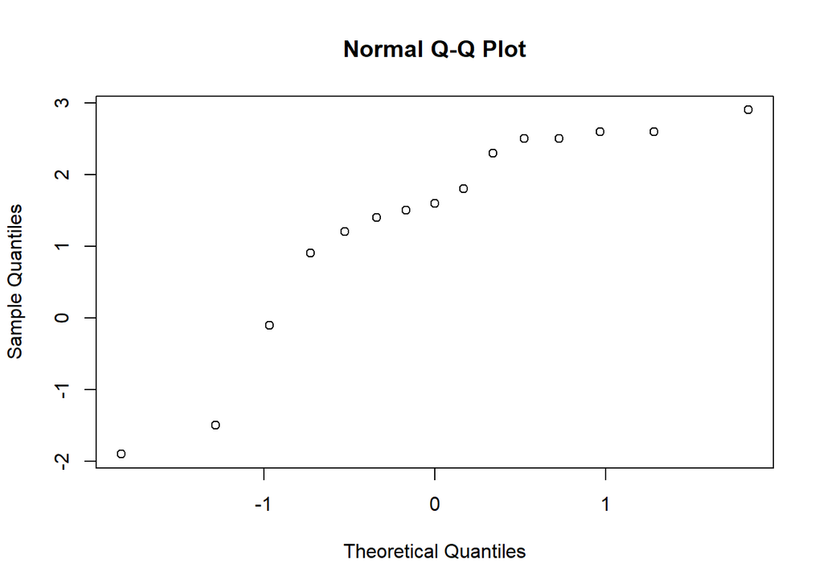

```r
dataB = c(2.5,1.8,2.6,-1.9,1.6,2.6,1.4,0.9,1.2,2.3,-1.5,1.5,2.5,2.9,-0.1)
qqnorm(dataB)
```

and compare to the normal distribution QQ plot, I can tell it is against from a normal population.

## 1c

The qq plot of the data is

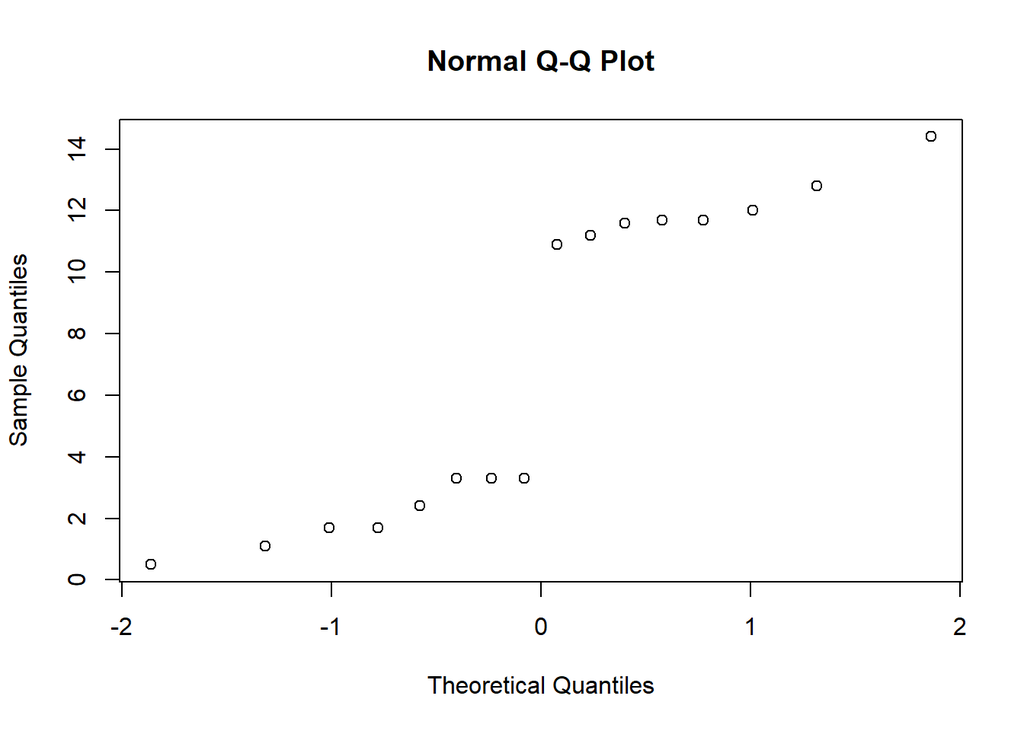

```r
dataC = c(3.3,1.7,3.3,3.3,2.4,0.5,1.1,1.7,12,14.4,12.8,11.2,10.9,11.7,11.7,11.6)
qqnorm(dataC)
```

and compare to the normal distribution QQ plot, I can tell it is against from a normal population.

# 2 Fiber

The dietary fiber tablet is on average, 250 g of the supplement,with a standard deviation of 2 g

## 2a

The probability a randomly selected bottle weighs between 246g and 254g is

```r
pnorm(q = 254, mean = 250, sd = 2) - pnorm(q = 246, mean = 250, sd = 2)
```

```
## [1] 0.9544997
```

## 2b

100 bottles are selected randomly. The probability that their average weight is less than 250g is

```r
pnorm(q = 250, mean = 250, sd = 2 / sqrt(100))
```

```
## [1] 0.5
```

Central Limit Theorem (CLT) states that for N sufficiently large, the sample mean (X bar) follows approximately N(mu, (sd / sqrt(n))^2), so you can use that expression to find the probability.

# 3 Bulls

The mean weight is 1135lb and the standard deviation is 97lb. 40 bulls are randomly selected and loaded on the car. The probability that their combined weight exceeds 46000lb is

```r
1 - pnorm(q = 46000 / 40, mean = 1135, sd = 97 / sqrt(40))
```

```
## [1] 0.1640312
```